# Exploratory Data Analysis

Author

“Kristin Lloyd”

```r
options(repos = c(CRAN = "https://cran.rstudio.com"))
install.packages("tidyverse")
install.packages("usmap")
install.packages("networkD3")
install.packages("coin")
library(tidyverse)
library(tidyr)
library(reshape2)
library(usmap)
library(networkD3)
library(coin)
library(dplyr)
library(ggplot2)
```

Let’s load my processed dataset and look at my model labels. My main interpretations are in exploratory_data_analysis.html. The main point of this document is to show the differences between the model labeled visualizations and the indepdently labeled visualizations.

```r
df <- read.csv("../Data/processed-data/Senators_sentiment.csv")
head(df)
```

```
  first      last party state ideology_score  region year source likes shares
1  Alex   Padilla     D    CA         -0.375 Midwest 2023      X   104     28
2  Alex   Padilla     D    CA         -0.375 Midwest 2024      X    68     33
3  Alex   Padilla     D    CA         -0.375 Midwest 2023      X    92     20
4   Amy Klobuchar     D    MN         -0.283 Midwest 2023      X    18      9
5   Amy Klobuchar     D    MN         -0.283 Midwest 2022      X  1600    269
6   Amy Klobuchar     D    MN         -0.283 Midwest 2021      X   510     96
  views
1  4756
2  8176
3  6516
4  3985
5
6
                                                                                                                                                                            message
1                                                           climate change harming health planetit hurting nation infrastructure joined discus need invest climate resilient system
2                       news billion dollar epa headed ca port build zeroemission infrastructure historic funding huge step forward addressing climate change improving air quality
3                                         hottest year record earth science clear ca wait act climate change time clean energy transition clean job curbing greenhouse gas emission
4 climate crisis happening need confront sense urgency community historically disenfranchised likely experience disproportionate share effect climate change environmental disaster
5                       climate change isnt happening sometime futureits happening meet moment invest clean energy pave way carbon neutral economy time pas inflation reduction act
6                                                                                                                                cant ignore climate change existential threat time
  independent_label sentiment model_label
1       opportunity         1           1
2       opportunity         1           1
3       opportunity         1           1
4       opportunity         1           1
5       opportunity         1           1
6       opportunity         1           1
```

This dataset has a model_label column from my sentiment model. Let’s see how the model’s predictions effect my visualizations.

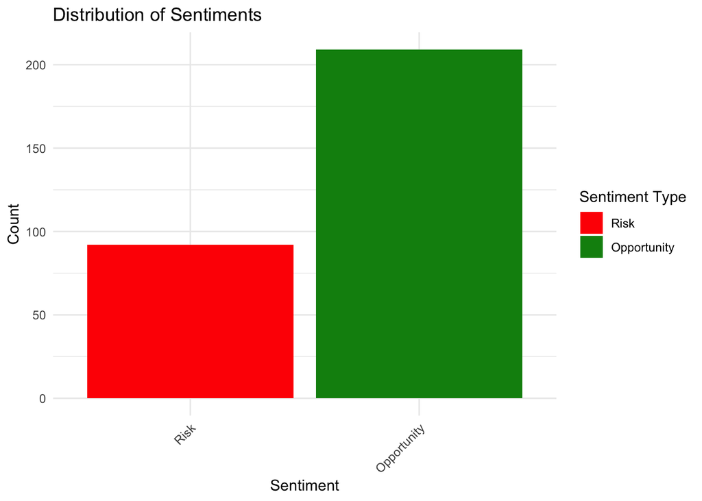

```r
independent_counts <- df %>%
  filter(!is.na(model_label)) %>%
  count(model_label)

independent_counts <- independent_counts %>%
  mutate(model_label = factor(model_label, levels = c(-1, 1), labels = c("Risk", "Opportunity")))

ggplot(independent_counts, aes(x = model_label, y = n, fill = model_label)) +
  geom_bar(stat = "identity") +
  scale_fill_manual(values = c("Risk" = "red", "Opportunity" = "#078d0f")) +
  labs(
    title = "Distribution of Sentiments",
    x = "Sentiment",
    y = "Count",
    fill = "Sentiment Type"
  ) +
  theme_minimal() +
  theme(axis.text.x = element_text(angle = 45, hjust = 1))
```

As shown in my indepdent label visualization, opportunity sentiment is more prevalent than risk sentiment.

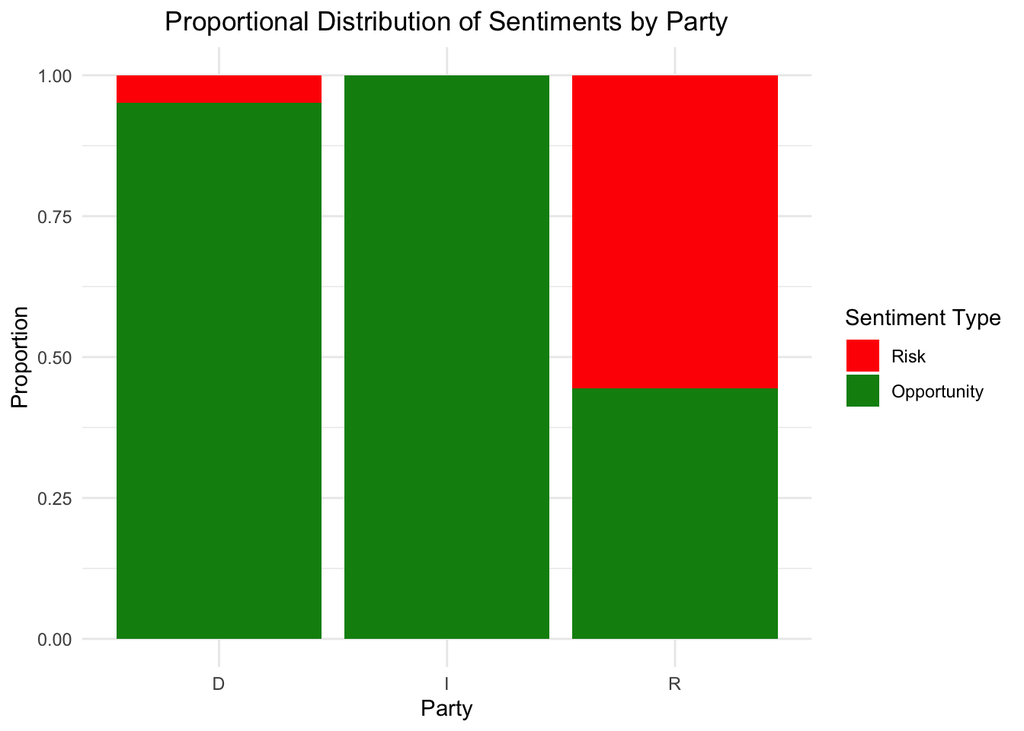

```r
grouped_data <- df %>%
  filter(!is.na(model_label)) %>%
  group_by(party, model_label) %>%
  summarise(Count = n(), .groups = 'drop') %>%
  group_by(party) %>%
  mutate(Proportion = Count / sum(Count))

grouped_data <- grouped_data %>%
  mutate(model_label = factor(model_label, levels = c(-1, 1), labels = c("Risk", "Opportunity")))

# Mosaic Plot
ggplot(grouped_data, aes(x = party, y = Proportion, fill = model_label)) +
  geom_bar(stat = "identity", position = "fill") +
  scale_fill_manual(values = c("Risk" = "red", "Opportunity" = "#078d0f")) +
  labs(
    title = "Proportional Distribution of Sentiments by Party",
    x = "Party",
    y = "Proportion",
    fill = "Sentiment Type"
  ) +
  theme_minimal() +
  theme(
    axis.text.x = element_text(angle = 0),
    legend.position = "right",
    plot.title = element_text(hjust = 0.5)
  )
```

```r
flows_party <- df %>%
  filter(party %in% c("R", "I","D")) %>%
  mutate(
    sentiment_label = ifelse(model_label == 1, "Opportunity", "Risk")
  ) %>%
  group_by(party, sentiment_label) %>%
  summarise(value = n(), .groups = "drop")

nodes_party <- data.frame(
  name = c(
    unique(flows_party$party),
    unique(flows_party$sentiment_label)
  )
)

links_party <- flows_party %>%
  mutate(
    source = match(party, nodes_party$name) - 1,
    target = match(sentiment_label, nodes_party$name) - 1,
    value = value
  )

sankeyNetwork(
  Links = links_party,
  Nodes = nodes_party,
  Source = "source",
  Target = "target",
  Value = "value",
  NodeID = "name",
  sinksRight = TRUE,
  nodeWidth = 30,
  fontSize = 12,
  height = 600,
  width = 1000
)
```

```
Links is a tbl_df. Converting to a plain data frame.
```

[interactive chart not shown]

These two plots mostly agree with the indepdent label plots. However, Democrats now have some risky sentiment and Republicans have a much larger split.

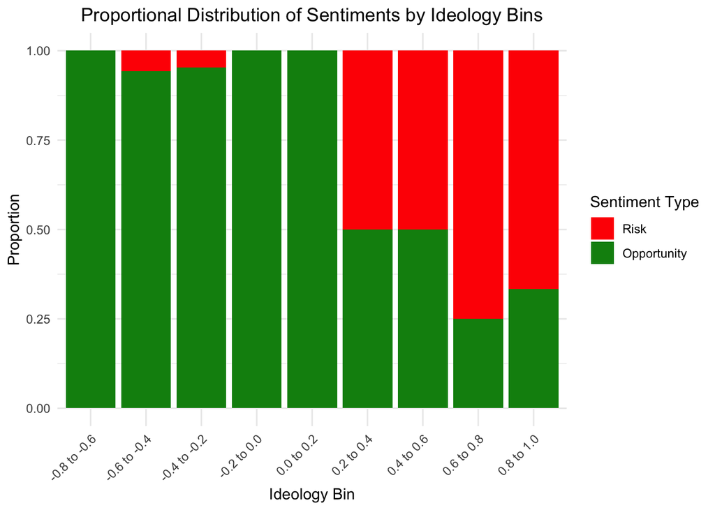

```r
bins <- c(-1.0, -0.8, -0.6, -0.4, -0.2, 0.0, 0.2, 0.4, 0.6, 0.8, 1.0)
labels <- c(
  "-1.0 to -0.8", "-0.8 to -0.6", "-0.6 to -0.4", "-0.4 to -0.2",
  "-0.2 to 0.0", "0.0 to 0.2", "0.2 to 0.4", "0.4 to 0.6",
  "0.6 to 0.8", "0.8 to 1.0"
)

grouped_data <- df %>%
  filter(!is.na(model_label)) %>%
  mutate(
    ideology_bin = cut(ideology_score, breaks = bins, labels = labels, include.lowest = TRUE),
    model_label = factor(model_label, levels = c(-1, 1), labels = c("Risk", "Opportunity"))
  ) %>%
  group_by(ideology_bin, model_label) %>%
  summarise(Count = n(), .groups = 'drop') %>%
  group_by(ideology_bin) %>%
  mutate(Proportion = Count / sum(Count))

# Mosaic Plot for Ideology Bins
ggplot(grouped_data, aes(x = ideology_bin, y = Proportion, fill = model_label)) +
  geom_bar(stat = "identity", position = "fill") +
  scale_fill_manual(values = c("Risk" = "red", "Opportunity" = "#078d0f")) +
  labs(
    title = "Proportional Distribution of Sentiments by Ideology Bins",
    x = "Ideology Bin",
    y = "Proportion",
    fill = "Sentiment Type"
  ) +
  theme_minimal() +
  theme(
    axis.text.x = element_text(angle = 45, hjust = 1),
    legend.position = "right",
    plot.title = element_text(hjust = 0.5)
  )
```

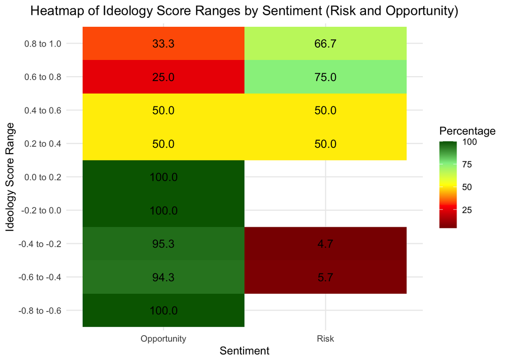

```r
heatmap_data <- df %>%
  mutate(
    ideology_bin = cut(ideology_score,
                      breaks = seq(-1, 1, by = 0.2),
                      labels = c("-1.0 to -0.8",
                               "-0.8 to -0.6",
                               "-0.6 to -0.4",
                               "-0.4 to -0.2",
                               "-0.2 to 0.0",
                               "0.0 to 0.2",
                               "0.2 to 0.4",
                               "0.4 to 0.6",
                               "0.6 to 0.8",
                               "0.8 to 1.0")),
    model_label = ifelse(model_label == 1, "Opportunity", "Risk")
  ) %>%
  group_by(ideology_bin, model_label) %>%
  summarise(count = n(), .groups = "drop") %>%
  group_by(ideology_bin) %>%
  mutate(percentage = (count / sum(count)) * 100) %>%
  ungroup()

heatmap_data <- heatmap_data %>%
  filter(!is.na(ideology_bin))

# Heatmap
ggplot(heatmap_data, aes(x = model_label, y = ideology_bin, fill = percentage)) +
  geom_tile() +
  geom_text(aes(label = sprintf("%.1f", percentage)),
            color = "black", size = 4) +
  scale_fill_gradientn(
    colors = c("darkred", "red", "yellow", "lightgreen", "darkgreen"),
    values = scales::rescale(c(0, 25, 50, 75, 100))
  ) +
  labs(
    title = "Heatmap of Ideology Score Ranges by Sentiment (Risk and Opportunity)",
    x = "Sentiment",
    y = "Ideology Score Range",
    fill = "Percentage"
  ) +
  theme_minimal() +
  theme(
    axis.text.x = element_text(angle = 0, hjust = 0.5),
    axis.text.y = element_text(hjust = 1),
    plot.title = element_text(hjust = 0.5)
  )
```

The heatmap does hold the relationship held in the indepdent label plot. However, in the indepdent plot, 0.2 to 0.4 was all green. Another big difference is the 0.8 to 1.0 showing a 33/66 split whereas the indepdent labels showed a 0/100 split. The model’s visualizations show that the top conservative score is not associated with the most risky sentiment.

To test this relationship between ideology and sentiment, a correlation analysis would be beneficial.

```r
# Correlation test between ideology score and sentiment
ideology_correlation <- cor.test(df$ideology_score, df$model_label)
print("\nCorrelation between Ideology Score and Sentiment:")
```

```
[1] "\nCorrelation between Ideology Score and Sentiment:"
```

```r
print(ideology_correlation)
```

```
    Pearson's product-moment correlation

data:  df$ideology_score and df$model_label
t = -11.955, df = 299, p-value < 2.2e-16
alternative hypothesis: true correlation is not equal to 0
95 percent confidence interval:
 -0.6405536 -0.4869364
sample estimates:
       cor
-0.5686831
```

The result of the correlation test is -0.5686831. This is less strong than the -0.8 value I got in my independent label analysis. This means that the model did not produce as telling of a model.

Let’s do some analysis by region now, starting with some maps.

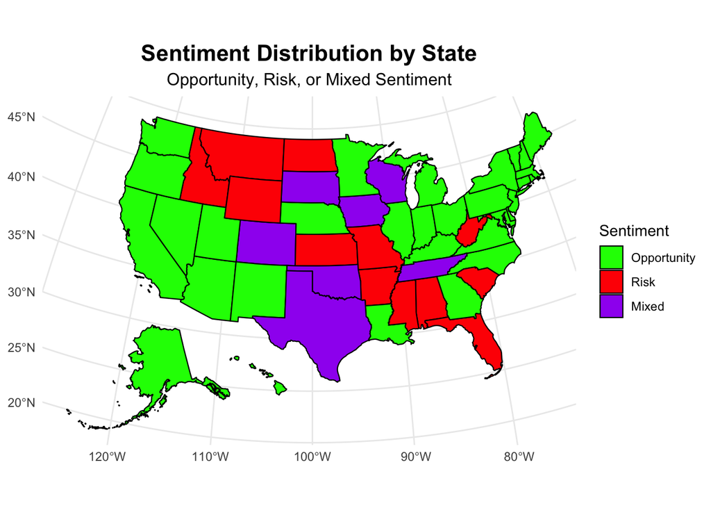

```r
df <- read.csv("../Data/processed-data/Senators_sentiment.csv")

state_sentiment <- df %>%
  filter(!is.na(model_label)) %>%
  group_by(state, model_label) %>%
  summarise(count = n(), .groups = "drop") %>%
  group_by(state) %>%
  mutate(
    total = sum(count),
    proportion = count / total
  ) %>%
  summarise(
    max_proportion = max(proportion),
    sentiment_label = case_when(
      max_proportion < 0.6 ~ "mixed",
      model_label[which.max(proportion)] == -1 ~ "risk",
      model_label[which.max(proportion)] == 1 ~ "opportunity"
    ),
    .groups = "drop"
  )

# Plot the US map with mixed sentiment
plot_usmap(data = state_sentiment, values = "sentiment_label", regions = "states") +
  scale_fill_manual(
    values = c(
      "opportunity" = "green",
      "risk" = "red",
      "mixed" = "purple"
    ),
    name = "Sentiment",
    breaks = c("opportunity", "risk", "mixed"),
    labels = c("Opportunity", "Risk", "Mixed")
  ) +
  labs(
    title = "Sentiment Distribution by State",
    subtitle = "Opportunity, Risk, or Mixed Sentiment"
  ) +
  theme_minimal() +
  theme(
    legend.position = "right",
    plot.title = element_text(hjust = 0.5, size = 16, face = "bold"),
    plot.subtitle = element_text(hjust = 0.5, size = 12)
  )
```

Texas, Wisconsin, Iowa, Tennessee, Oklahoma, South Dakota, and Colorado now have mixed sentiment. Wisconsin and South Dakota are the only state that previously had mixed sentiment out of these states. Based on independent labels, Pennsylvania, Alaska, and South Dakota should have mixed sentiment. The model’s labels also classified a lot of states as having opportunistic sentiment when the indepdent labels claim that it should be negative sentiment.

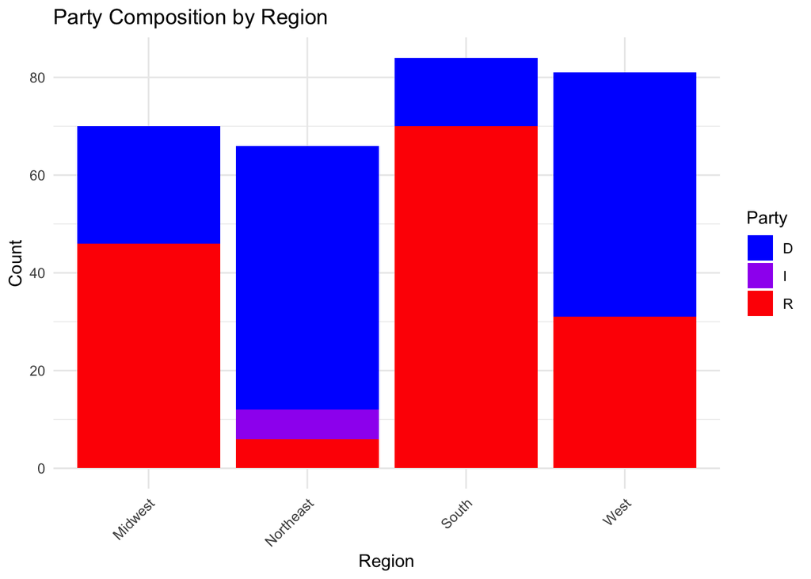

```r
# Region and Party
party_region_counts <- df %>%
  group_by(region, party) %>%
  summarise(Count = n(), .groups = "drop")

ggplot(party_region_counts, aes(x = region, y = Count, fill = party)) +
  geom_bar(stat = "identity") +
  scale_fill_manual(values = c("D" = "blue", "R" = "red", "I" = "purple")) +
  labs(
    title = "Party Composition by Region",
    x = "Region",
    y = "Count",
    fill = "Party"
  ) +
  theme_minimal() +
  theme(
    axis.text.x = element_text(angle = 45, hjust = 1)
  )
```

This relationship is still preserved compared to the indepdently labeled model.

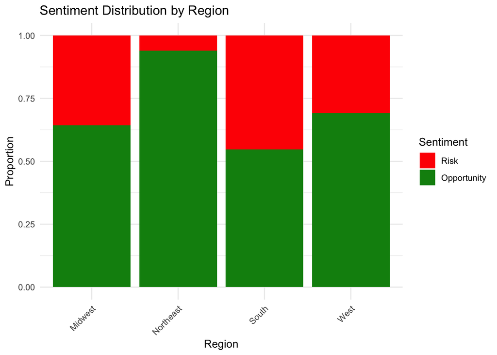

```r
# Region and Sentiment
sentiment_region_props <- df %>%
  group_by(region, model_label) %>%
  summarise(Count = n(), .groups = "drop") %>%
  group_by(region) %>%
  mutate(Proportion = Count / sum(Count))

ggplot(sentiment_region_props, aes(x = region, y = Proportion, fill = as.factor(model_label))) +
  geom_bar(stat = "identity", position = "fill") +
  scale_fill_manual(values = c("-1" = "red", "1" = "#078d0f"), labels = c("Risk", "Opportunity")) +
  labs(
    title = "Sentiment Distribution by Region",
    x = "Region",
    y = "Proportion",
    fill = "Sentiment"
  ) +
  theme_minimal() +
  theme(
    axis.text.x = element_text(angle = 45, hjust = 1)
  )
```

The relationships are still preserved.

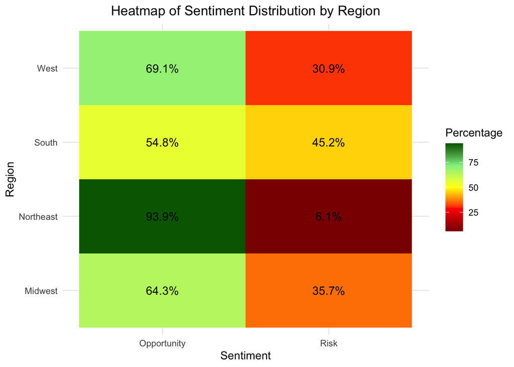

```r
heatmap_data <- df %>%
  mutate(
    model_label = ifelse(model_label == 1, "Opportunity", "Risk")
  ) %>%
  group_by(region, model_label) %>%
  summarise(count = n(), .groups = "drop") %>%
  group_by(region) %>%
  mutate(percentage = (count / sum(count)) * 100) %>%
  ungroup()

# Heatmap
ggplot(heatmap_data, aes(x = model_label, y = region, fill = percentage)) +
  geom_tile() +
  geom_text(aes(label = sprintf("%.1f%%", percentage)),
            color = "black", size = 4) +
  scale_fill_gradientn(
    colors = c("darkred", "red", "yellow", "lightgreen", "darkgreen"),
    values = scales::rescale(c(0, 25, 50, 75, 100)),
    name = "Percentage"
  ) +
  labs(
    title = "Heatmap of Sentiment Distribution by Region",
    x = "Sentiment",
    y = "Region"
  ) +
  theme_minimal() +
  theme(
    axis.text.x = element_text(angle = 0, hjust = 0.5),
    axis.text.y = element_text(hjust = 1),
    plot.title = element_text(hjust = 0.5)
  )
```

```r
flows_region <- df %>%
  mutate(
    sentiment_label = ifelse(model_label == 1, "Opportunity", "Risk")
  ) %>%
  group_by(region, sentiment_label) %>%
  summarise(value = n(), .groups = "drop")

nodes_region <- data.frame(
  name = c(
    unique(flows_region$region),
    unique(flows_region$sentiment_label)
  )
)

links_region <- flows_region %>%
  mutate(
    source = match(region, nodes_region$name) - 1,
    target = match(sentiment_label, nodes_region$name) - 1,
    value = value
  )

sankeyNetwork(
  Links = links_region,
  Nodes = nodes_region,
  Source = "source",
  Target = "target",
  Value = "value",
  NodeID = "name",
  sinksRight = TRUE,
  nodeWidth = 30,
  fontSize = 12,
  height = 600,
  width = 1000
)
```

```
Links is a tbl_df. Converting to a plain data frame.
```

[interactive chart not shown]

## Conclusion

The analysis reveals a divide in how U.S. senators view climate change. However, the model did not do as good of a job as the independent label visualizations did at showing the correlation between ideology and sentiment.